# Election 2024 Forecast

## Data Sources:

## VACCINE DATA:

##for 2024 : USED Data from CDC on Uptake of 2023/24 Seasonal Covid Shot. a few states data were missing full population vaccine uptake %, so ## data was imputed by running regression on percentage of population 18+ and 65+ ## For 2020- used Vaccine uptake by state for year 2021. For 2022: Used Booster Uptake by STate for year. ## Theory is that Covid Vaccine uptake is the most reliable predictor of Democratic Party allegiance.

## For 2024 Mail IN ballots- some states did not have Ballots requested yet ast of 10/21- Washington Sate, a state with ALL Mail IN ballots, the full registered votors from 2023 was used. For alaska, not avail yet, and Requested mail in ballots for 2022 General was used. Mississippi- mail in requested for 2022 was used. For 2024 the states Alabama, Arkansas, Oklahoma and Mississippi, the Mail IN Ballot Request total was used from 2022 General Election. For New York and New Hampshire, data was imputed using Average of BLue State % of total voting population

## Comments: what is important is to train the model to be able to predict the states where there will be a close race, for highly blue or highly red states, imputed data based on historical numbers is not expected to skew the model.

## Outliers- removed Washington DC fo 2021 as an outlier as it skewed model. Removed Alaska for 2022.

## Historical Election Results - MIT Election LAB and FIveThirtyEight Github

```r
## Read in Historical data for training

data = read.csv("model_data_outlier_remove.csv",sep = ",",header = TRUE)
```

```r
# Z Scoring the Vax data in order to normalize due to declining Vax Numbers year over year

data <- data %>%
  group_by(YEAR) %>%  # Grouping by YEAR
  mutate(Z_Score_VAX_PERCENT_POP = (VAX_PERCENT_POP - mean(VAX_PERCENT_POP)) / sd(VAX_PERCENT_POP)) %>%
  ungroup()  # Ungroup after calculation

# View the updated data
head(data)
```

| YEAR | STATE | SWING_LAST | PREV_WIN_DEM | POPULATION | MAIL_BALLOTS_REQUESTED | ALL_MAIL_STATE | BIRTHS | POVERTY_RATE | DOM_MIG_RATE | FERTILITY_RATE | DEATHS | DEATH_RATE | MENTAL_HEALTH | VAX_PERCENT_POP | VAX_18PLUS | VAX_65PLUS | PFIZER | MODERNA | PFIZER_LESS_MODERNA | TURNOUT | REP_VOTES | DEM_VOTES | DEM_VOTE_PERCENT | REP_VOTE_PERCENT | MARGIN_DEM | Z_Score_VAX_PERCENT_POP |
| --- | --- | --- | --- | --- | --- | --- | --- | --- | --- | --- | --- | --- | --- | --- | --- | --- | --- | --- | --- | --- | --- | --- | --- | --- | --- | --- |
| 2021 | AK | 0 | 0 | 731544 | 195515 | 0 | 9822 | 10.2 | -2.827193 | 68.1 | 4453 | 603.8 | 36.79 | 56.3 | 67.7 | 84.2 | 264490 | 167095 | 97395 | 343729 | 189951 | 153778 | 42.77195 | 52.83314 | -10.06 | -0.4735032 |
| 2021 | AL | 0 | 0 | 4903173 | 331104 | 0 | 58615 | 12.9 | 5.856038 | 61.7 | 54352 | 1112.0 | 37.02 | 47.6 | 57.8 | 79.6 | 1366194 | 1061466 | 304728 | 2290794 | 1441170 | 849624 | 36.56999 | 62.03164 | -25.46 | -1.5069900 |
| 2021 | AR | 0 | 0 | 3017801 | 876929 | 0 | 36564 | 14.1 | 6.338793 | 63.2 | 32336 | 1072.9 | 39.10 | 51.2 | 61.3 | 78.3 | 901682 | 689591 | 212091 | 1184579 | 760647 | 423932 | 34.77506 | 62.39573 | -27.62 | -1.0793403 |
| 2021 | AZ | 0 | 0 | 7278736 | 3448181 | 0 | 79375 | 9.9 | 12.490343 | 56.7 | 59282 | 826.6 | 39.01 | 57.0 | 67.4 | 83.6 | 2694757 | 1731027 | 963730 | 3333829 | 1661686 | 1672143 | 49.36469 | 49.05598 | 0.31 | -0.3903491 |
| 2021 | CA | 0 | 1 | 39512180 | 22042262 | 0 | 446479 | 10.1 | -10.546858 | 55.4 | 268818 | 679.6 | 40.32 | 66.1 | 76.9 | 86.7 | 17174393 | 10063340 | 7111053 | 17116679 | 6006429 | 11110250 | 63.48395 | 34.32072 | 29.16 | 0.6906542 |
| 2021 | CO | 0 | 1 | 5758728 | 4111226 | 1 | 62869 | 9.3 | 1.606820 | 53.3 | 38526 | 676.4 | 43.30 | 66.2 | 76.5 | 89.2 | 2386800 | 1496432 | 890368 | 3168959 | 1364607 | 1804352 | 55.40000 | 41.90000 | 13.50 | 0.7025334 |

```r
# Apply the log transformation to the MAIL_BALLOTS_REQUESTED predictor
data$Log_MAIL_BALLOTS_REQUESTED <- log(data$MAIL_BALLOTS_REQUESTED + 1)


head(data)
```

| YEAR | STATE | SWING_LAST | PREV_WIN_DEM | POPULATION | MAIL_BALLOTS_REQUESTED | ALL_MAIL_STATE | BIRTHS | POVERTY_RATE | DOM_MIG_RATE | FERTILITY_RATE | DEATHS | DEATH_RATE | MENTAL_HEALTH | VAX_PERCENT_POP | VAX_18PLUS | VAX_65PLUS | PFIZER | MODERNA | PFIZER_LESS_MODERNA | TURNOUT | REP_VOTES | DEM_VOTES | DEM_VOTE_PERCENT | REP_VOTE_PERCENT | MARGIN_DEM | Z_Score_VAX_PERCENT_POP | Log_MAIL_BALLOTS_REQUESTED |
| --- | --- | --- | --- | --- | --- | --- | --- | --- | --- | --- | --- | --- | --- | --- | --- | --- | --- | --- | --- | --- | --- | --- | --- | --- | --- | --- | --- |
| 2021 | AK | 0 | 0 | 731544 | 195515 | 0 | 9822 | 10.2 | -2.827193 | 68.1 | 4453 | 603.8 | 36.79 | 56.3 | 67.7 | 84.2 | 264490 | 167095 | 97395 | 343729 | 189951 | 153778 | 42.77195 | 52.83314 | -10.06 | -0.4735032 | 12.18340 |
| 2021 | AL | 0 | 0 | 4903173 | 331104 | 0 | 58615 | 12.9 | 5.856038 | 61.7 | 54352 | 1112.0 | 37.02 | 47.6 | 57.8 | 79.6 | 1366194 | 1061466 | 304728 | 2290794 | 1441170 | 849624 | 36.56999 | 62.03164 | -25.46 | -1.5069900 | 12.71019 |
| 2021 | AR | 0 | 0 | 3017801 | 876929 | 0 | 36564 | 14.1 | 6.338793 | 63.2 | 32336 | 1072.9 | 39.10 | 51.2 | 61.3 | 78.3 | 901682 | 689591 | 212091 | 1184579 | 760647 | 423932 | 34.77506 | 62.39573 | -27.62 | -1.0793403 | 13.68418 |
| 2021 | AZ | 0 | 0 | 7278736 | 3448181 | 0 | 79375 | 9.9 | 12.490343 | 56.7 | 59282 | 826.6 | 39.01 | 57.0 | 67.4 | 83.6 | 2694757 | 1731027 | 963730 | 3333829 | 1661686 | 1672143 | 49.36469 | 49.05598 | 0.31 | -0.3903491 | 15.05336 |
| 2021 | CA | 0 | 1 | 39512180 | 22042262 | 0 | 446479 | 10.1 | -10.546858 | 55.4 | 268818 | 679.6 | 40.32 | 66.1 | 76.9 | 86.7 | 17174393 | 10063340 | 7111053 | 17116679 | 6006429 | 11110250 | 63.48395 | 34.32072 | 29.16 | 0.6906542 | 16.90847 |
| 2021 | CO | 0 | 1 | 5758728 | 4111226 | 1 | 62869 | 9.3 | 1.606820 | 53.3 | 38526 | 676.4 | 43.30 | 66.2 | 76.5 | 89.2 | 2386800 | 1496432 | 890368 | 3168959 | 1364607 | 1804352 | 55.40000 | 41.90000 | 13.50 | 0.7025334 | 15.22923 |

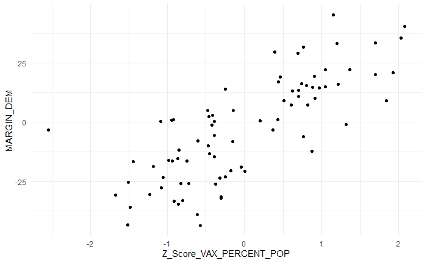

```r
#install libraries
#library(ggplot2)

## plot predictors against response to see correlations. See VAX_PERCENT_POP vs DEM_MARGIN AS EXAMPLE.

plot <- ggplot(data, aes_string(x = "Z_Score_VAX_PERCENT_POP", y = "MARGIN_DEM")) + geom_point() + theme_minimal()

print(plot)
```

```r
 ### Checking all predictors for interactions
model <- lm(MARGIN_DEM ~ (Z_Score_VAX_PERCENT_POP + MENTAL_HEALTH + DOM_MIG_RATE +
                          Log_MAIL_BALLOTS_REQUESTED + ALL_MAIL_STATE + FERTILITY_RATE + POVERTY_RATE +
                          DEATH_RATE + PREV_WIN_DEM + POPULATION)^2, data = data)
step_model <- stepAIC(model)
```

[output not shown]

```r
### InTERATION TERMS ## Creating interaction terms detected in previous stepAIC()

data <- data %>%
  mutate(
    # Interaction terms involving Z_Score_VAX_PERCENT_POP
    Z_VAX_MENTAL_HEALTH = Z_Score_VAX_PERCENT_POP * MENTAL_HEALTH,
    Z_VAX_DOM_MIG = Z_Score_VAX_PERCENT_POP * DOM_MIG_RATE,
    Z_VAX_LOG_MAIL_BALLOTS = Z_Score_VAX_PERCENT_POP * Log_MAIL_BALLOTS_REQUESTED,
    Z_VAX_ALL_MAIL = Z_Score_VAX_PERCENT_POP * ALL_MAIL_STATE,
    Z_VAX_POVERTY_RATE = Z_Score_VAX_PERCENT_POP * POVERTY_RATE,
    Z_VAX_DEATH_RATE = Z_Score_VAX_PERCENT_POP * DEATH_RATE,
    Z_VAX_PREV_WIN = Z_Score_VAX_PERCENT_POP * PREV_WIN_DEM,
    Z_VAX_POPULATION = Z_Score_VAX_PERCENT_POP * POPULATION,

    # Interaction terms involving MENTAL_HEALTH
    MENTAL_HEALTH_DOM_MIG = MENTAL_HEALTH * DOM_MIG_RATE,

    # Interaction terms involving DOM_MIG_RATE
    DOM_MIG_LOG_MAIL_BALLOTS = DOM_MIG_RATE * Log_MAIL_BALLOTS_REQUESTED,
    DOM_MIG_ALL_MAIL = DOM_MIG_RATE * ALL_MAIL_STATE,
    DOM_MIG_FERTILITY = DOM_MIG_RATE * FERTILITY_RATE,
    DOM_MIG_POVERTY_RATE = DOM_MIG_RATE * POVERTY_RATE,
    DOM_MIG_DEATH_RATE = DOM_MIG_RATE * DEATH_RATE,
    DOM_MIG_POPULATION = DOM_MIG_RATE * POPULATION,

    # Interaction terms involving Log_MAIL_BALLOTS_REQUESTED
    LOG_MAIL_BALLOTS_ALL_MAIL = Log_MAIL_BALLOTS_REQUESTED * ALL_MAIL_STATE,
    LOG_MAIL_BALLOTS_FERTILITY = Log_MAIL_BALLOTS_REQUESTED * FERTILITY_RATE,
    LOG_MAIL_BALLOTS_POPULATION = Log_MAIL_BALLOTS_REQUESTED * POPULATION,

    # Interaction terms involving ALL_MAIL_STATE
    ALL_MAIL_FERTILITY = ALL_MAIL_STATE * FERTILITY_RATE,
    ALL_MAIL_POPULATION = ALL_MAIL_STATE * POPULATION,

    # Interaction terms involving FERTILITY_RATE
    FERTILITY_POPULATION = FERTILITY_RATE * POPULATION,

    # Interaction terms involving POVERTY_RATE
    POVERTY_PREV_WIN = POVERTY_RATE * PREV_WIN_DEM,

    # Interaction terms involving DEATH_RATE
    DEATH_RATE_PREV_WIN = DEATH_RATE * PREV_WIN_DEM,

    # Interaction terms involving PREV_WIN_DEM
    PREV_WIN_POPULATION = PREV_WIN_DEM * POPULATION
  )
```

```r
###Linear REGRESSION WITH NEW INTERACTION TERMS

formula <- MARGIN_DEM ~ Z_Score_VAX_PERCENT_POP +  DOM_MIG_RATE + Log_MAIL_BALLOTS_REQUESTED + ALL_MAIL_STATE + FERTILITY_RATE + DEATH_RATE + PREV_WIN_DEM + POPULATION + Z_VAX_DOM_MIG + DOM_MIG_ALL_MAIL + Z_VAX_PREV_WIN

# Set up 10-fold cross-validation
train_control <- trainControl(method = "cv", number = 10)

# Train the linear model with 10-fold cross-validation
set.seed(123)  # For reproducibility
lm_model <- train(
  formula,
  data = data,
  method = "lm",
  trControl = train_control
)

# Print the results of the cross-validation
summary(lm_model)
```

```
Call:
lm(formula = .outcome ~ ., data = dat)

Residuals:
     Min       1Q   Median       3Q      Max
-21.3107  -5.0647   0.4391   4.5499  23.7337

Coefficients:
                             Estimate Std. Error t value Pr(>|t|)
(Intercept)                 3.987e+01  3.323e+01   1.200  0.23421
Z_Score_VAX_PERCENT_POP     4.841e+00  2.538e+00   1.907  0.06066 .
DOM_MIG_RATE               -1.646e-01  1.637e-01  -1.005  0.31819
Log_MAIL_BALLOTS_REQUESTED  2.398e+00  1.201e+00   1.996  0.04993 *
ALL_MAIL_STATE              7.465e+00  3.733e+00   2.000  0.04947 *
FERTILITY_RATE             -1.046e+00  3.295e-01  -3.175  0.00224 **
DEATH_RATE                 -2.188e-02  8.400e-03  -2.605  0.01124 *
PREV_WIN_DEM                1.454e+01  3.405e+00   4.272 6.08e-05 ***
POPULATION                  1.072e-07  1.979e-07   0.542  0.58974
Z_VAX_DOM_MIG              -5.369e-02  1.596e-01  -0.336  0.73756
DOM_MIG_ALL_MAIL           -1.416e+00  5.091e-01  -2.782  0.00696 **
Z_VAX_PREV_WIN              3.223e-01  3.151e+00   0.102  0.91884
---
Signif. codes:  0 ‘***’ 0.001 ‘**’ 0.01 ‘*’ 0.05 ‘.’ 0.1 ‘ ’ 1

Residual standard error: 9.126 on 69 degrees of freedom
Multiple R-squared:  0.8462,    Adjusted R-squared:  0.8217
F-statistic: 34.51 on 11 and 69 DF,  p-value: < 2.2e-16
```

```r
print(lm_model)
```

```
Linear Regression

81 samples
11 predictors

No pre-processing
Resampling: Cross-Validated (10 fold)
Summary of sample sizes: 73, 73, 73, 73, 73, 73, ...
Resampling results:

  RMSE      Rsquared   MAE
  9.728566  0.8497032  7.682155

Tuning parameter 'intercept' was held constant at a value of TRUE
```

```r
vif_values <- vif(lm_model$finalModel)
print(vif_values)
```

```
   Z_Score_VAX_PERCENT_POP               DOM_MIG_RATE Log_MAIL_BALLOTS_REQUESTED             ALL_MAIL_STATE
                  6.111607                   1.459821                   2.489235                   1.826262
            FERTILITY_RATE                 DEATH_RATE               PREV_WIN_DEM                 POPULATION
                  2.948913                   1.817053                   2.766408                   2.134108
             Z_VAX_DOM_MIG           DOM_MIG_ALL_MAIL             Z_VAX_PREV_WIN
                  1.918529                   1.535422                   3.867387
```

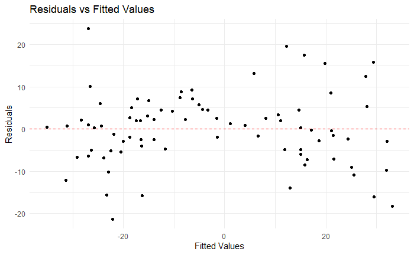

```r
## Testing Model Assumptions to make sure none are violated
# Test model assumptions and create residuals plot
# Extract residuals and fitted values
fitted_values <- predict(lm_model, newdata = data)
residuals <- data$MARGIN_DEM - fitted_values

# Plot residuals vs. fitted values
ggplot(data, aes(x = fitted_values, y = residuals)) +
  geom_point() +
  geom_hline(yintercept = 0, linetype = "dashed", color = "red") +
  labs(title = "Residuals vs Fitted Values", x = "Fitted Values", y = "Residuals") +
  theme_minimal()
```

```
[1] 68 50
```

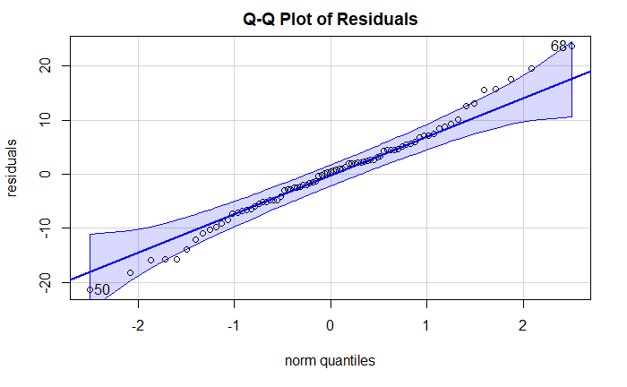

```r
# Q-Q plot to check normality of residuals
qqPlot(residuals, main = "Q-Q Plot of Residuals")
```

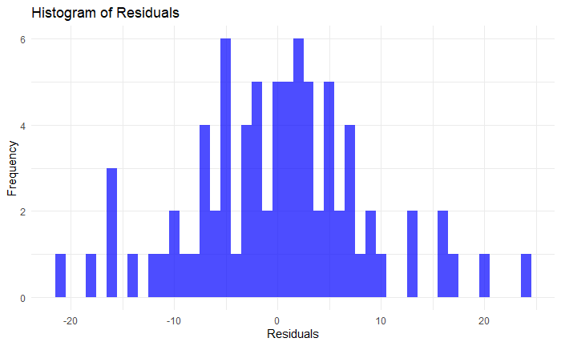

```r
# Plot histogram of residuals
ggplot(data.frame(residuals), aes(x = residuals)) +
  geom_histogram(binwidth = 1, fill = "blue", alpha = 0.7) +
  labs(title = "Histogram of Residuals", x = "Residuals", y = "Frequency") +
  theme_minimal()
```

```r
# Check for homoscedasticity
ncvTest(lm(formula, data = data))
```

```
Non-constant Variance Score Test
Variance formula: ~ fitted.values
Chisquare = 1.560274, Df = 1, p = 0.21163
```

```r
# Check for multicollinearity
vif_values <- vif(lm(formula, data = data))
print(vif_values)
```

```
   Z_Score_VAX_PERCENT_POP               DOM_MIG_RATE Log_MAIL_BALLOTS_REQUESTED             ALL_MAIL_STATE
                  6.111607                   1.459821                   2.489235                   1.826262
            FERTILITY_RATE                 DEATH_RATE               PREV_WIN_DEM                 POPULATION
                  2.948913                   1.817053                   2.766408                   2.134108
             Z_VAX_DOM_MIG           DOM_MIG_ALL_MAIL             Z_VAX_PREV_WIN
                  1.918529                   1.535422                   3.867387
```

```r
## Logistic regression- Converting response to binary
# Create the DEM_WIN column based on the MARGIN_DEM column
data$DEM_WIN <- ifelse(data$MARGIN_DEM > 0, 1, 0)

# View the first few rows to check the new column
head(data)
```

| YEAR | STATE | SWING_LAST | PREV_WIN_DEM | POPULATION | MAIL_BALLOTS_REQUESTED | ALL_MAIL_STATE | BIRTHS | POVERTY_RATE | DOM_MIG_RATE | FERTILITY_RATE | DEATHS | DEATH_RATE | MENTAL_HEALTH | VAX_PERCENT_POP | VAX_18PLUS | VAX_65PLUS | PFIZER | MODERNA | PFIZER_LESS_MODERNA | TURNOUT | REP_VOTES | DEM_VOTES | DEM_VOTE_PERCENT | REP_VOTE_PERCENT | MARGIN_DEM | Z_Score_VAX_PERCENT_POP | Log_MAIL_BALLOTS_REQUESTED | Z_VAX_MENTAL_HEALTH | Z_VAX_DOM_MIG | … |
| --- | --- | --- | --- | --- | --- | --- | --- | --- | --- | --- | --- | --- | --- | --- | --- | --- | --- | --- | --- | --- | --- | --- | --- | --- | --- | --- | --- | --- | --- | --- |
| 2021 | AK | 0 | 0 | 731544 | 195515 | 0 | 9822 | 10.2 | -2.827193 | 68.1 | 4453 | 603.8 | 36.79 | 56.3 | 67.7 | 84.2 | 264490 | 167095 | 97395 | 343729 | 189951 | 153778 | 42.77195 | 52.83314 | -10.06 | -0.4735032 | 12.18340 | -17.42018 | 1.338685 | … |
| 2021 | AL | 0 | 0 | 4903173 | 331104 | 0 | 58615 | 12.9 | 5.856038 | 61.7 | 54352 | 1112.0 | 37.02 | 47.6 | 57.8 | 79.6 | 1366194 | 1061466 | 304728 | 2290794 | 1441170 | 849624 | 36.56999 | 62.03164 | -25.46 | -1.5069900 | 12.71019 | -55.78877 | -8.824990 | … |
| 2021 | AR | 0 | 0 | 3017801 | 876929 | 0 | 36564 | 14.1 | 6.338793 | 63.2 | 32336 | 1072.9 | 39.10 | 51.2 | 61.3 | 78.3 | 901682 | 689591 | 212091 | 1184579 | 760647 | 423932 | 34.77506 | 62.39573 | -27.62 | -1.0793403 | 13.68418 | -42.20221 | -6.841714 | … |
| 2021 | AZ | 0 | 0 | 7278736 | 3448181 | 0 | 79375 | 9.9 | 12.490343 | 56.7 | 59282 | 826.6 | 39.01 | 57.0 | 67.4 | 83.6 | 2694757 | 1731027 | 963730 | 3333829 | 1661686 | 1672143 | 49.36469 | 49.05598 | 0.31 | -0.3903491 | 15.05336 | -15.22752 | -4.875595 | … |
| 2021 | CA | 0 | 1 | 39512180 | 22042262 | 0 | 446479 | 10.1 | -10.546858 | 55.4 | 268818 | 679.6 | 40.32 | 66.1 | 76.9 | 86.7 | 17174393 | 10063340 | 7111053 | 17116679 | 6006429 | 11110250 | 63.48395 | 34.32072 | 29.16 | 0.6906542 | 16.90847 | 27.84718 | -7.284232 | … |
| 2021 | CO | 0 | 1 | 5758728 | 4111226 | 1 | 62869 | 9.3 | 1.606820 | 53.3 | 38526 | 676.4 | 43.30 | 66.2 | 76.5 | 89.2 | 2386800 | 1496432 | 890368 | 3168959 | 1364607 | 1804352 | 55.40000 | 41.90000 | 13.50 | 0.7025334 | 15.22923 | 30.41970 | 1.128845 | … |

```r
#creating a test/train split for log reg

# Code chunk not needed as we are doing Cross Validation in an Elastic Net logistic regression model.

#trainIndex <- createDataPartition(data$DEM_WIN, p = 0.7, list = FALSE)
#train_data <- data[trainIndex, ]
#test_data <- data[-trainIndex, ]
```

```r
# Prepare data for logistic regression, use Elastic Net Regularization
# Prepare data for logistic regression
x <- as.matrix(data[, c("Z_Score_VAX_PERCENT_POP", "MENTAL_HEALTH", "DOM_MIG_RATE", "Z_VAX_MENTAL_HEALTH", "Log_MAIL_BALLOTS_REQUESTED", "ALL_MAIL_STATE", "FERTILITY_RATE", "DEATH_RATE", "PREV_WIN_DEM", "Z_VAX_DOM_MIG", "DOM_MIG_ALL_MAIL", "Z_VAX_PREV_WIN")])
y <- factor(data$DEM_WIN, levels = c(0, 1))

# Set up cross-validation for Elastic Net
train_control <- trainControl(method = "cv", number = 10)

# Train Elastic Net logistic regression model
set.seed(123)
logistic_model <- train(
  x, y,
  method = "glmnet",
  trControl = train_control,
  tuneGrid = expand.grid(alpha = seq(0, 1, length = 10), lambda = seq(0.001, 1, length = 100)),
  family = "binomial"
)

# Print cross-validation results
print(logistic_model)
```

```
glmnet

81 samples
12 predictors
 2 classes: '0', '1'

No pre-processing
Resampling: Cross-Validated (10 fold)
Summary of sample sizes: 72, 73, 73, 73, 73, 73, ...
Resampling results across tuning parameters:

  alpha      lambda      Accuracy   Kappa
  0.0000000  0.00100000  0.9000000  0.800
  0.0000000  0.01109091  0.9000000  0.800
  0.0000000  0.02118182  0.9000000  0.800
  0.0000000  0.03127273  0.9000000  0.800
  0.0000000  0.04136364  0.9000000  0.800
  0.0000000  0.05145455  0.9000000  0.800
  0.0000000  0.06154545  0.9000000  0.800
  0.0000000  0.07163636  0.9000000  0.800
  0.0000000  0.08172727  0.8875000  0.775
  0.0000000  0.09181818  0.8875000  0.775
  0.0000000  0.10190909  0.8875000  0.775
  0.0000000  0.11200000  0.8875000  0.775
  0.0000000  0.12209091  0.8875000  0.775
  0.0000000  0.13218182  0.8875000  0.775
  0.0000000  0.14227273  0.8875000  0.775
  0.0000000  0.15236364  0.8875000  0.775
  0.0000000  0.16245455  0.8875000  0.775
  0.0000000  0.17254545  0.8875000  0.775
  0.0000000  0.18263636  0.8875000  0.775
  0.0000000  0.19272727  0.8875000  0.775
  0.0000000  0.20281818  0.8875000  0.775
  0.0000000  0.21290909  0.8875000  0.775
  0.0000000  0.22300000  0.8875000  0.775
  0.0000000  0.23309091  0.8875000  0.775
  0.0000000  0.24318182  0.8875000  0.775
  0.0000000  0.25327273  0.8875000  0.775
  0.0000000  0.26336364  0.8875000  0.775
  0.0000000  0.27345455  0.8875000  0.775
```

[output cut: 211 more lines]

```
  0.2222222  0.39454545  0.9000000  0.800
  0.2222222  0.40463636  0.9000000  0.800
  0.2222222  0.41472727  0.9000000  0.800
  0.2222222  0.42481818  0.9000000  0.800
  0.2222222  0.43490909  0.9000000  0.800
  0.2222222  0.44500000  0.9000000  0.800
  0.2222222  0.45509091  0.9000000  0.800
  0.2222222  0.46518182  0.9000000  0.800
  0.2222222  0.47527273  0.9000000  0.800
  0.2222222  0.48536364  0.9000000  0.800
  0.2222222  0.49545455  0.9000000  0.800
 [ reached getOption("max.print") -- omitted 750 rows ]

Accuracy was used to select the optimal model using the largest value.
The final values used for the model were alpha = 0.7777778 and lambda = 0.02118182.
```

```r
# Predict probabilities on the dataset
predicted_prob <- predict(logistic_model$finalModel, newx = x, s = logistic_model$bestTune$lambda, type = "response")

# Classify predictions as 1 or 0 based on a threshold of 0.5
predicted_class <- ifelse(predicted_prob > 0.5, 1, 0)

# Store the predicted responses and actual responses in data frames
predicted_df <- data.frame(Predicted = predicted_class)
actual_df <- data.frame(Actual = y)

# Convert to factors for confusion matrix calculation
predicted_factor <- factor(predicted_class, levels = c(0, 1))
actual_factor <- factor(y, levels = c(0, 1))

# Calculate the confusion matrix
conf_matrix <- confusionMatrix(predicted_factor, actual_factor)
print(conf_matrix)
```

```
Confusion Matrix and Statistics

          Reference
Prediction  0  1
         0 40  2
         1  1 38

               Accuracy : 0.963
                 95% CI : (0.8956, 0.9923)
    No Information Rate : 0.5062
    P-Value [Acc > NIR] : <2e-16

                  Kappa : 0.9259

 Mcnemar's Test P-Value : 1

            Sensitivity : 0.9756
            Specificity : 0.9500
         Pos Pred Value : 0.9524
         Neg Pred Value : 0.9744
             Prevalence : 0.5062
         Detection Rate : 0.4938
   Detection Prevalence : 0.5185
      Balanced Accuracy : 0.9628

       'Positive' Class : 0
```

```r
# Calculate accuracy, sensitivity, and specificity
accuracy <- conf_matrix$overall["Accuracy"]
sensitivity <- conf_matrix$byClass["Sensitivity"]
specificity <- conf_matrix$byClass["Specificity"]

# Print accuracy metrics
cat("Accuracy:", accuracy, "\n")
```

```
Accuracy: 0.962963
```

```r
cat("Sensitivity:", sensitivity, "\n")
```

```
Sensitivity: 0.9756098
```

```r
cat("Specificity:", specificity, "\n")
```

```
Specificity: 0.95
```

```r
# Train Random Forest model with cross-validation
set.seed(123)  # For reproducibility

# Define the formula for the model
formula <- MARGIN_DEM ~ Z_Score_VAX_PERCENT_POP + Log_MAIL_BALLOTS_REQUESTED + Z_VAX_DOM_MIG +  ALL_MAIL_STATE + DOM_MIG_RATE + FERTILITY_RATE + DEATH_RATE + PREV_WIN_DEM + POPULATION


random_forest_model <- train(
  formula,
  data = data,
  method = "rf",
  trControl = train_control,
  tuneLength = 10
)
# Print the results of the cross-validation for Random Forest
print(random_forest_model)
```

```
Random Forest

81 samples
 9 predictor

No pre-processing
Resampling: Cross-Validated (10 fold)
Summary of sample sizes: 73, 73, 73, 73, 73, 73, ...
Resampling results across tuning parameters:

  mtry  RMSE      Rsquared   MAE
  2     9.306675  0.8574422  6.904622
  3     9.122339  0.8556096  6.645591
  4     9.002699  0.8567280  6.700043
  5     8.945368  0.8546023  6.708133
  6     9.054326  0.8512090  6.820544
  7     9.192507  0.8450260  6.939060
  8     9.215688  0.8453826  7.013382
  9     9.290559  0.8447069  7.112448

RMSE was used to select the optimal model using the smallest value.
The final value used for the model was mtry = 5.
```

```r
print(random_forest_model$results)
```

|  | mtry | RMSE | Rsquared | MAE | RMSESD | RsquaredSD | MAESD |
| --- | --- | --- | --- | --- | --- | --- | --- |
| 1 | 2 | 9.306675 | 0.8574422 | 6.904622 | 2.022317 | 0.04120101 | 1.537167 |
| 2 | 3 | 9.122339 | 0.8556096 | 6.645591 | 2.278860 | 0.05709149 | 1.722687 |
| 3 | 4 | 9.002699 | 0.8567280 | 6.700043 | 2.274499 | 0.05971009 | 1.777293 |
| 4 | 5 | 8.945368 | 0.8546023 | 6.708133 | 2.366594 | 0.06453591 | 1.875798 |
| 5 | 6 | 9.054326 | 0.8512090 | 6.820544 | 2.535678 | 0.07316626 | 2.074214 |
| 6 | 7 | 9.192507 | 0.8450260 | 6.939060 | 2.438281 | 0.07128919 | 2.075173 |
| 7 | 8 | 9.215688 | 0.8453826 | 7.013382 | 2.514325 | 0.07220064 | 2.198712 |
| 8 | 9 | 9.290559 | 0.8447069 | 7.112448 | 2.357462 | 0.06691861 | 2.117600 |

```r
# Summary of the Random Forest model
print(random_forest_model)
```

```
Random Forest

81 samples
 9 predictor

No pre-processing
Resampling: Cross-Validated (10 fold)
Summary of sample sizes: 73, 73, 73, 73, 73, 73, ...
Resampling results across tuning parameters:

  mtry  RMSE      Rsquared   MAE
  2     9.306675  0.8574422  6.904622
  3     9.122339  0.8556096  6.645591
  4     9.002699  0.8567280  6.700043
  5     8.945368  0.8546023  6.708133
  6     9.054326  0.8512090  6.820544
  7     9.192507  0.8450260  6.939060
  8     9.215688  0.8453826  7.013382
  9     9.290559  0.8447069  7.112448

RMSE was used to select the optimal model using the smallest value.
The final value used for the model was mtry = 5.
```

```r
# Extract variable importance from Random Forest model
rf_importance <- varImp(random_forest_model, scale = FALSE)
print(rf_importance)
```

```
rf variable importance
```

|  | Overall |
| --- | --- |
| PREV_WIN_DEM | 13183.2864 |
| Z_Score_VAX_PERCENT_POP | 9438.0609 |
| FERTILITY_RATE | 4015.2939 |
| Log_MAIL_BALLOTS_REQUESTED | 3604.7865 |
| POPULATION | 2468.6312 |
| DOM_MIG_RATE | 1222.6342 |
| DEATH_RATE | 1131.7840 |
| Z_VAX_DOM_MIG | 1071.8252 |
| ALL_MAIL_STATE | 274.6782 |

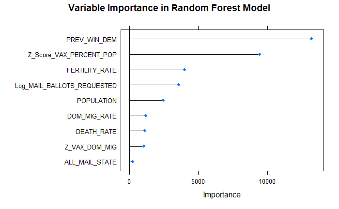

```r
# Plot variable importance
plot(rf_importance, main = "Variable Importance in Random Forest Model")
```

```r
### FINAL STEP 1: TRAINING ALL MODELS ON FULL DATA SET ###

# (a) Train the Linear Model (glm) for MARGIN_DEM
lm_model <- lm(MARGIN_DEM ~ Z_Score_VAX_PERCENT_POP +  DOM_MIG_RATE + Log_MAIL_BALLOTS_REQUESTED + ALL_MAIL_STATE + FERTILITY_RATE + DEATH_RATE + PREV_WIN_DEM + POPULATION + Z_VAX_DOM_MIG + DOM_MIG_ALL_MAIL + Z_VAX_PREV_WIN, data = data)

x <- as.matrix(data[, c("Z_Score_VAX_PERCENT_POP", "MENTAL_HEALTH", "DOM_MIG_RATE", "Z_VAX_MENTAL_HEALTH", "Log_MAIL_BALLOTS_REQUESTED", "ALL_MAIL_STATE", "FERTILITY_RATE", "DEATH_RATE", "PREV_WIN_DEM", "Z_VAX_DOM_MIG", "DOM_MIG_ALL_MAIL", "Z_VAX_PREV_WIN")])
y <- factor(data$DEM_WIN, levels = c(0, 1))

# (b) # Train Elastic Net logistic regression model on full dataset
log_model <- glmnet(
  x, y,
  alpha = 0.5, # You can adjust alpha between 0 (Ridge) and 1 (Lasso)
  lambda = 0.01, # Adjust lambda as needed
  family = "binomial"
)



# (c) Train the Random Forest Model for MARGIN_DEM
rf_model <- randomForest(MARGIN_DEM ~ Z_Score_VAX_PERCENT_POP + Log_MAIL_BALLOTS_REQUESTED + Z_VAX_DOM_MIG +  ALL_MAIL_STATE + DOM_MIG_RATE + FERTILITY_RATE + DEATH_RATE + PREV_WIN_DEM + POPULATION,
                         data = data, ntree = 200)
```

```r
### STEP 2: LOAD new PREDICTION SET, DO DATA TRANSFORMATIONS FOR ABSENTEE BALLOTS, VAX_PERCENT, and INTERACTION TERMS


# Step 3: Load the new prediction dataset
predict_data <- read.csv("predict_data.csv", sep = ",", header = TRUE)

# Step 4 - DATA TRANSFORMATIONS

## Z Scoring VAX Data
predict_data <- predict_data %>%
  group_by(YEAR) %>%  # Grouping by YEAR
  mutate(Z_Score_VAX_PERCENT_POP = (VAX_PERCENT_POP - mean(VAX_PERCENT_POP)) / sd(VAX_PERCENT_POP)) %>%
  ungroup()  # Ungroup after calculation


# Transform MAIL_BALLOTS_REQUESTED TO ADJUST FOR HEAVY TAIL
predict_data$Log_MAIL_BALLOTS_REQUESTED <- log(predict_data$MAIL_BALLOTS_REQUESTED + 1)


# Create new interaction terms in predict_data
predict_data <- predict_data %>%
  mutate(
    Z_VAX_DOM_MIG = Z_Score_VAX_PERCENT_POP * DOM_MIG_RATE,
    DOM_MIG_ALL_MAIL = DOM_MIG_RATE * ALL_MAIL_STATE,
    Z_VAX_PREV_WIN = Z_Score_VAX_PERCENT_POP * PREV_WIN_DEM,
    Z_VAX_MENTAL_HEALTH = Z_Score_VAX_PERCENT_POP * MENTAL_HEALTH
  )

# View the updated data
head(predict_data)
```

| YEAR | STATE | SWING_LAST | PREV_WIN_DEM | POPULATION | MAIL_BALLOTS_REQUESTED | ALL_MAIL_STATE | BIRTHS | POVERTY_RATE | DOM_MIG_RATE | FERTILITY_RATE | DEATHS | DEATH_RATE | MENTAL_HEALTH | VAX_PERCENT_POP | VAX_18PLUS | VAX_65PLUS | PFIZER | MODERNA | PFIZER_LESS_MODERNA | TURNOUT | REP_VOTES | DEM_VOTES | DEM_VOTE_PERCENT | REP_VOTE_PERCENT | MARGIN_DEM | Z_Score_VAX_PERCENT_POP | Log_MAIL_BALLOTS_REQUESTED | Z_VAX_DOM_MIG | DOM_MIG_ALL_MAIL | … |
| --- | --- | --- | --- | --- | --- | --- | --- | --- | --- | --- | --- | --- | --- | --- | --- | --- | --- | --- | --- | --- | --- | --- | --- | --- | --- | --- | --- | --- | --- | --- |
| 2024 | AK | NA | 0 | 726305 | 49002 | 0 | NA | 10.1 | 7.096186 | 61.65701 | 5529 | 753.7 | 24.70 | 9.26 | 10.90 | 30.07 | NA | NA | NA | NA | NA | NA | NA | NA | NA | -0.5845870 | 10.799637 | -4.1483380 | 0.000000 | … |
| 2024 | AL | NA | 0 | 4893409 | 318706 | 0 | NA | 14.2 | -4.825859 | 57.85420 | 59237 | 1167.4 | 22.20 | 4.97 | 6.15 | 16.46 | NA | NA | NA | NA | NA | NA | NA | NA | NA | -1.4823702 | 12.672027 | 7.1537090 | 0.000000 | … |
| 2024 | AR | NA | 0 | 3012505 | 21247 | 0 | NA | 13.8 | 7.814272 | 59.11753 | 35758 | 1174.1 | 23.00 | 7.17 | 8.90 | 23.65 | NA | NA | NA | NA | NA | NA | NA | NA | NA | -1.0219685 | 9.964018 | -7.9859400 | 0.000000 | … |
| 2024 | AZ | NA | 1 | 7380697 | 3298587 | 0 | NA | 11.9 | 7.262514 | 54.13993 | 69335 | 942.2 | 20.73 | 8.81 | 10.26 | 24.46 | NA | NA | NA | NA | NA | NA | NA | NA | NA | -0.6787600 | 15.009005 | -4.9295045 | 0.000000 | … |
| 2024 | CA | NA | 1 | 39144646 | 22730542 | 0 | NA | 11.9 | -4.804488 | 50.34910 | 294735 | 755.2 | 20.53 | 14.57 | 16.96 | 38.47 | NA | NA | NA | NA | NA | NA | NA | NA | NA | 0.5266552 | 16.939220 | -2.5303086 | 0.000000 | … |
| 2024 | CO | NA | 1 | 5773714 | 4252159 | 1 | NA | 8.5 | 3.271196 | 50.22279 | 44971 | 770.1 | 21.12 | 13.50 | 17.10 | 26.90 | NA | NA | NA | NA | NA | NA | NA | NA | NA | 0.3027325 | 15.262938 | 0.9902975 | 3.271196 | … |

```r
NA
```

```r
# Step 5: Make predictions on the new prediction dataset

# (a) Linear Model Predictions
predict_data$linear_predict <- predict(lm_model, newdata = predict_data)

# (b) Logistic Regression Predictions (use a threshold of 0.5)
predict_x <- as.matrix(predict_data[, c("Z_Score_VAX_PERCENT_POP", "MENTAL_HEALTH", "DOM_MIG_RATE", "Z_VAX_MENTAL_HEALTH", "Log_MAIL_BALLOTS_REQUESTED", "ALL_MAIL_STATE", "FERTILITY_RATE", "DEATH_RATE", "PREV_WIN_DEM", "Z_VAX_DOM_MIG", "DOM_MIG_ALL_MAIL", "Z_VAX_PREV_WIN")])
predict_prob <- predict(log_model, newx = predict_x, type = "response")
predict_data$elastic_net_predict <- ifelse(predict_prob > 0.5, 1, 0)


# (c) Random Forest Model Predictions
predict_data$rf_predict <- predict(rf_model, newdata = predict_data)

# Step 5: View the updated prediction dataset
head(predict_data)
```

| YEAR | STATE | SWING_LAST | PREV_WIN_DEM | POPULATION | MAIL_BALLOTS_REQUESTED | ALL_MAIL_STATE | BIRTHS | POVERTY_RATE | DOM_MIG_RATE | FERTILITY_RATE | DEATHS | DEATH_RATE | MENTAL_HEALTH | VAX_PERCENT_POP | VAX_18PLUS | VAX_65PLUS | PFIZER | MODERNA | PFIZER_LESS_MODERNA | TURNOUT | REP_VOTES | DEM_VOTES | DEM_VOTE_PERCENT | REP_VOTE_PERCENT | MARGIN_DEM | Z_Score_VAX_PERCENT_POP | Log_MAIL_BALLOTS_REQUESTED | Z_VAX_DOM_MIG | DOM_MIG_ALL_MAIL | … |
| --- | --- | --- | --- | --- | --- | --- | --- | --- | --- | --- | --- | --- | --- | --- | --- | --- | --- | --- | --- | --- | --- | --- | --- | --- | --- | --- | --- | --- | --- | --- |
| 2024 | AK | NA | 0 | 726305 | 49002 | 0 | NA | 10.1 | 7.096186 | 61.65701 | 5529 | 753.7 | 24.70 | 9.26 | 10.90 | 30.07 | NA | NA | NA | NA | NA | NA | NA | NA | NA | -0.5845870 | 10.799637 | -4.1483380 | 0.000000 | … |
| 2024 | AL | NA | 0 | 4893409 | 318706 | 0 | NA | 14.2 | -4.825859 | 57.85420 | 59237 | 1167.4 | 22.20 | 4.97 | 6.15 | 16.46 | NA | NA | NA | NA | NA | NA | NA | NA | NA | -1.4823702 | 12.672027 | 7.1537090 | 0.000000 | … |
| 2024 | AR | NA | 0 | 3012505 | 21247 | 0 | NA | 13.8 | 7.814272 | 59.11753 | 35758 | 1174.1 | 23.00 | 7.17 | 8.90 | 23.65 | NA | NA | NA | NA | NA | NA | NA | NA | NA | -1.0219685 | 9.964018 | -7.9859400 | 0.000000 | … |
| 2024 | AZ | NA | 1 | 7380697 | 3298587 | 0 | NA | 11.9 | 7.262514 | 54.13993 | 69335 | 942.2 | 20.73 | 8.81 | 10.26 | 24.46 | NA | NA | NA | NA | NA | NA | NA | NA | NA | -0.6787600 | 15.009005 | -4.9295045 | 0.000000 | … |
| 2024 | CA | NA | 1 | 39144646 | 22730542 | 0 | NA | 11.9 | -4.804488 | 50.34910 | 294735 | 755.2 | 20.53 | 14.57 | 16.96 | 38.47 | NA | NA | NA | NA | NA | NA | NA | NA | NA | 0.5266552 | 16.939220 | -2.5303086 | 0.000000 | … |
| 2024 | CO | NA | 1 | 5773714 | 4252159 | 1 | NA | 8.5 | 3.271196 | 50.22279 | 44971 | 770.1 | 21.12 | 13.50 | 17.10 | 26.90 | NA | NA | NA | NA | NA | NA | NA | NA | NA | 0.3027325 | 15.262938 | 0.9902975 | 3.271196 | … |

```r
NA
NA
```

```r
# Step 6: Write predictions to new csv
write.csv(predict_data, "predict_data_with_predictions_2.csv", row.names = FALSE)
```

```r
#Step 7: Create new data frame with selected columns from 'data' and 'predict_data'
selected_columns <- c("YEAR", "STATE", "PREV_WIN_DEM", "POPULATION", "MAIL_BALLOTS_REQUESTED", "ALL_MAIL_STATE", "FERTILITY_RATE", "POVERTY_RATE", "DOM_MIG_RATE", "DEATH_RATE", "MENTAL_HEALTH", "VAX_PERCENT_POP", "Z_Score_VAX_PERCENT_POP", "Log_MAIL_BALLOTS_REQUESTED", "Z_VAX_DOM_MIG", "DOM_MIG_ALL_MAIL", "Z_VAX_PREV_WIN", "Z_VAX_MENTAL_HEALTH")

combined_data <- rbind(
  data[, selected_columns],
  predict_data[, selected_columns]
)

# View the combined data frame
head(combined_data)
```

| YEAR | STATE | PREV_WIN_DEM | POPULATION | MAIL_BALLOTS_REQUESTED | ALL_MAIL_STATE | FERTILITY_RATE | POVERTY_RATE | DOM_MIG_RATE | DEATH_RATE | MENTAL_HEALTH | VAX_PERCENT_POP | Z_Score_VAX_PERCENT_POP | Log_MAIL_BALLOTS_REQUESTED | Z_VAX_DOM_MIG | DOM_MIG_ALL_MAIL | Z_VAX_PREV_WIN | Z_VAX_MENTAL_HEALTH |
| --- | --- | --- | --- | --- | --- | --- | --- | --- | --- | --- | --- | --- | --- | --- | --- | --- | --- |
| 2021 | AK | 0 | 731544 | 195515 | 0 | 68.1 | 10.2 | -2.827193 | 603.8 | 36.79 | 56.3 | -0.4735032 | 12.18340 | 1.338685 | 0.00000 | 0.0000000 | -17.42018 |
| 2021 | AL | 0 | 4903173 | 331104 | 0 | 61.7 | 12.9 | 5.856038 | 1112.0 | 37.02 | 47.6 | -1.5069900 | 12.71019 | -8.824990 | 0.00000 | 0.0000000 | -55.78877 |
| 2021 | AR | 0 | 3017801 | 876929 | 0 | 63.2 | 14.1 | 6.338793 | 1072.9 | 39.10 | 51.2 | -1.0793403 | 13.68418 | -6.841714 | 0.00000 | 0.0000000 | -42.20221 |
| 2021 | AZ | 0 | 7278736 | 3448181 | 0 | 56.7 | 9.9 | 12.490343 | 826.6 | 39.01 | 57.0 | -0.3903491 | 15.05336 | -4.875595 | 0.00000 | 0.0000000 | -15.22752 |
| 2021 | CA | 1 | 39512180 | 22042262 | 0 | 55.4 | 10.1 | -10.546858 | 679.6 | 40.32 | 66.1 | 0.6906542 | 16.90847 | -7.284232 | 0.00000 | 0.6906542 | 27.84718 |
| 2021 | CO | 1 | 5758728 | 4111226 | 1 | 53.3 | 9.3 | 1.606820 | 676.4 | 43.30 | 66.2 | 0.7025334 | 15.22923 | 1.128845 | 1.60682 | 0.7025334 | 30.41970 |

```r
NA
```

```r
write.csv(combined_data, "combined_data.csv", row.names = FALSE)
```

```r
## Swing State Analysis
# Update YEAR values from 2021 to 2020 in combined_data (ELECTION DATA FROM )
combined_data$YEAR[combined_data$YEAR == 2021] <- 2020

# Define swing states
swing_states <- c("AZ", "NV", "WI", "GA", "NC", "PA", "MI")

# Filter data for swing states
swing_data <- combined_data %>% filter(STATE %in% swing_states)
```

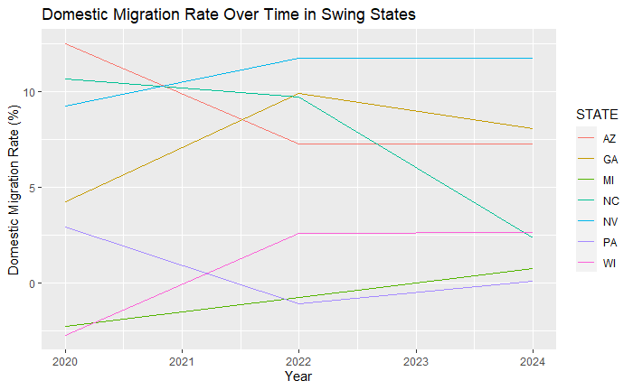

```r
swing_summary <- swing_data %>%
  group_by(STATE, YEAR) %>%
  summarize(
    avg_vax_uptake = mean(Z_Score_VAX_PERCENT_POP, na.rm = TRUE),
    avg_mail_in_ballots = mean(MAIL_BALLOTS_REQUESTED, na.rm = TRUE),
    avg_dom_mig_rate = mean(DOM_MIG_RATE, na.rm = TRUE)
  )
# (c) Domestic Migration Rate Over Time
ggplot(swing_summary, aes(x = YEAR, y = avg_dom_mig_rate, color = STATE)) +
  geom_line() +
  labs(title = "Domestic Migration Rate Over Time in Swing States", x = "Year", y = "Domestic Migration Rate (%)")
```

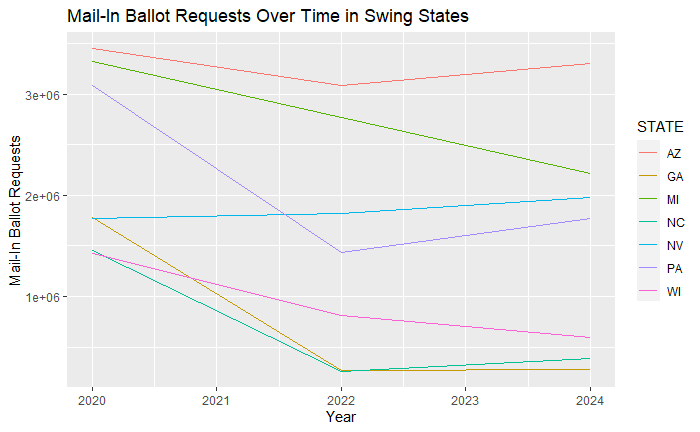

```r
# (b) Mail-In Ballot Requests Over Time
ggplot(swing_summary, aes(x = YEAR, y = avg_mail_in_ballots, color = STATE)) +
  geom_line() +
  labs(title = "Mail-In Ballot Requests Over Time in Swing States", x = "Year", y = "Mail-In Ballot Requests")
```

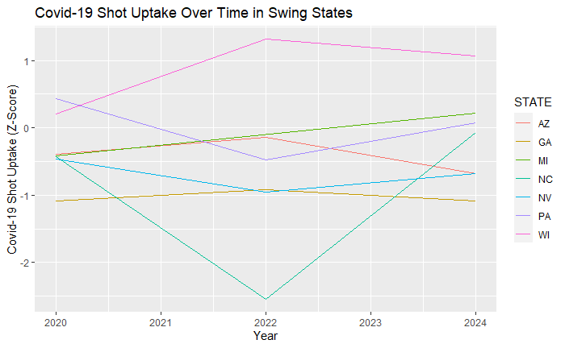

```r
# (a) Vaccine Uptake Over Time
ggplot(swing_summary, aes(x = YEAR, y = avg_vax_uptake, color = STATE)) +
  geom_line() +
  labs(title = "Covid-19 Shot Uptake Over Time in Swing States", x = "Year", y = "Covid-19 Shot Uptake (Z-Score)")
```